# Getting Started with R Markdown

K. D. Erickson

5/20/2021

# Why R Markdown?

Keep notes about what and *why* you are doing something right along with your code

Useful for:

- Keeping a coding notebook
- Sharing with collaborators (especially those who don’t use R!)
- Publish reports/summaries
- Share code snippets/results on your website
- Teaching
- Visualizing large plots
- Keeping track of figures

# Orientation to a R Markdown file

## The header

An R Markdown file (*.Rmd) starts with a YAML header that sets certain document properties:

[figure not shown]

`output:` controls what type of document your markdown file will render to:

- html_document
- html_notebook
- pdf_document
- word_document

Because Markdown was originally developed for html, there are the most options available for html documents.

RStudio includes a bunch of commonly used options to select from in the Output Options… menu:

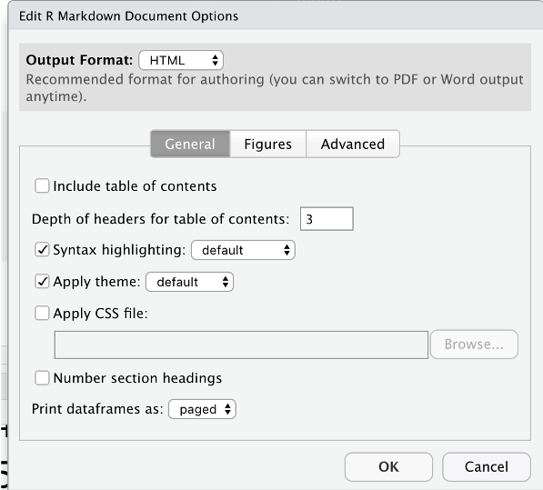

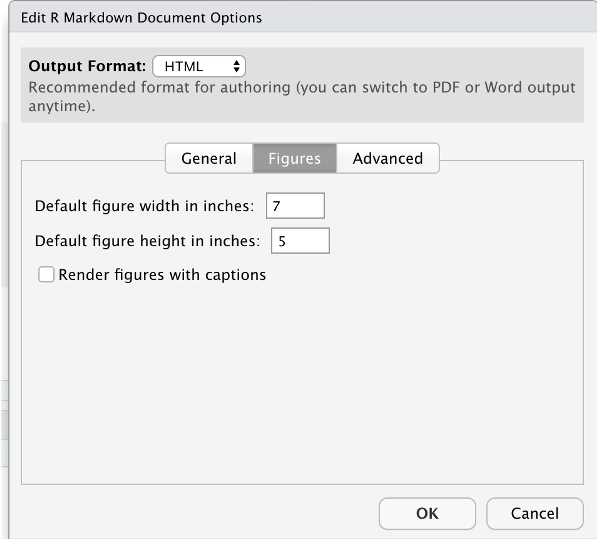

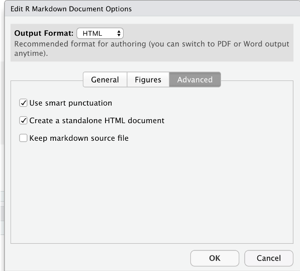

Selecting choices and clicking ok will update the YAML header for you.

## Including multiple plots on the same line

To control how many plots are shown in one row, use `fig.show="hold"` and `out.width="XX%$`, where XX is 50% if you want two per line, 33% for three, 25% for 4, etc.

```r
plot(cars, pch=19)
plot(pressure, pch=19, type='b')
hist(cars$speed, col="grey")
hist(pressure$temperature, col="lightblue")
```

[output not shown]

What if we use par?

```r
par(mfrow=c(2,2))
plot(cars, pch=19)
plot(pressure, pch=19, type='b')
hist(cars$speed, col="grey")
hist(pressure$temperature, col="lightblue")
```

[output not shown]

## Including tables

```r
kable(head(pressure), caption = "This is my table caption.", digits=2)
#digits: controls how many digits to display in the table
```

[output not shown]

## Writing out equations

You can make use of $\LaTeX$ to write out mathematical equations, either inline like so: $y = \beta_0 + \beta_1 x_1 + \beta_2 x_{1}^2$

or on a separate line in display mode:

$$\int_{-\infty}^{\infty} \mu_x dx$$

See https://detexify.kirelabs.org/classify.html for a helpful link for looking up $\LaTeX$ symbols, either by drawing them or looking through a chart. And see https://www.overleaf.com/learn/latex/Learn_LaTeX_in_30_minutes for a brief intro to the power of $\LaTeX$